# Baker et al. simulation

Stijn Masschelein

# Introduction

This is a non necessarily coherent collection of code that I used to develop my course material to teach the [Baker, Larcker, and Wang](https://doi.org/10.1016/j.jfineco.2022.01.004) paper on staggered difference-in-difference, specifically simulation 6. I used the opportunity to familiarise myself with some of the [fastverse packages](https://sebkrantz.github.io/fastverse/) and I sprinkled some timing tests in the code here and there.[^1]. If you are going to work with large datasets and just summarising the data takes a lot of computing time, switching over from the tidyverse to (some of) the fastverse packages might be a worthwhile investment of your time[^2]. My other interest in writing this all up is that it will allow me to test other estimators and other data generating processes.

# R Setup

The `here` package helps with managing the different files associated with my teaching material. The `tidyverse` is what I normally use for data management and what I teach because I like the pedagogy but it’s not as fast compared to `data.table` and `collapse`. `cowplot` is my preference for decent default in plots. `RPostgress` is necessary to get the data from the WRDS server. `fixest` is the gold standard for regression estimators with fixed effects as of the time of writing. `modelsummary` is a package to create tables from regression objects. `gof_omit` and `stars` will override some of the defaults in `modelsummary.`run_wrds` is just a boolean to control whether I want to rerun the WRDS query.[^3]

```r
library(here)
library(tidyverse)
```

```r
library(cowplot)
theme_set(theme_cowplot())
library(collapse)
library(data.table)
library(RPostgres)
library(fixest)
library(modelsummary)
gof_omit = "IC|Log|Adj|Ps"
stars = c("*" = 0.1, "**" = .05, "***" = .01)
i_am("auxilary/baker_simulation.Rmd")
```

```
## here() starts at /Users/stijn/Dropbox/Teaching/lecturenotes/method_package
```

```r
run_wrds <- FALSE
file <- here("data", "roas.RDS")
```

# WRDS

The data comes from WRDS which has [pretty good documentation](https://wrds-www.wharton.upenn.edu/pages/support/programming-wrds/programming-r/r-from-your-computer/) on how to set up `R` and `Rstudio` to work. You do need an WRDS account though and they are not cheap. The code in this section only runs if `run_wrds` is TRUE because I assume it does not change. [^4].

```r
wrds <- dbConnect(Postgres(),
                  host='wrds-pgdata.wharton.upenn.edu',
                  port=9737,
                  dbname='wrds',
                  user='stimas',
                  sslmode='require')
```

I used [Andrew Baker’s Github repository](https://github.com/andrewchbaker/JFE_DID/blob/main/Code/1e.%20Alternative%20Event%20Study%20Estimators.R) for the paper to replicate the underlying data but implement them in my own way. I don’t fully replicate the sample but it’s good enough for my sample. I have slightly more observations and one day I will figure out where I went wrong.

```r
sql1 <- "SELECT fyear, gvkey, oibdp, at, sich
       FROM COMP.FUNDA
       WHERE fyear > 1978 AND fyear < 2016 AND indfmt = 'INDL' AND datafmt = 'STD'
       AND popsrc = 'D' AND consol = 'C' AND fic = 'USA'"
res <- dbSendQuery(wrds, sql1)
dt <- as_tibble(dbFetch(res)) %>%
  rename_all(tolower)
dbClearResult(res)
roas <- dt %>%
  rename(year = fyear, firm = gvkey) %>%
  filter(!is.na(year), !is.na(at), !is.na(oibdp), at > 0) %>%
  group_by(firm) %>% arrange(year) %>%
  mutate(roa = oibdp / lag(at)) %>%
  ungroup() %>%
  select(year, firm, roa, sich) %>%
  filter(!is.na(roa), year > 1979)
glimpse(roas)
```

```r
sql2 <- "SELECT gvkey, incorp, sic FROM crsp.comphead"
res <- dbSendQuery(wrds, sql2)
dt2 <- as_tibble(dbFetch(res)) %>%
  rename_all(tolower)
dbClearResult(res)
roas <- rename(dt2, firm = gvkey) %>%
  filter(!is.na(incorp) & incorp %in% state.abb) %>%
  right_join(roas) %>%
  mutate(sich = coalesce(sich, sic)) %>%
  filter(!sich %in% c(6000:6999)) %>%
  glimpse()
```

```r
roas <- roas %>%
  group_by(firm) %>%
  add_tally() %>%
  filter(n >= 5) %>%
  ungroup()
glimpse(roas)

 # winsorize ROA at 99, and censor at -1
wins <- function(x) {
  # winsorize and return
  case_when(
    is.na(x) ~ NA_real_,
    x < -1 ~ -1,
    x > quantile(x, 0.99, na.rm = TRUE) ~ quantile(x, 0.99, na.rm = TRUE),
    TRUE ~ x
  )
}

# winsorize ROA by year
roas <- roas %>%
  group_by(year) %>%
  mutate(roa = wins(roa)) %>%
  arrange(firm, year) %>%
  ungroup()
```

```r
saveRDS(roas, file)
```

# Create Data

Let’s read the data back in.

```r
roas <- readRDS(file)
mtime <- file.info((file))$mtime
```

The data was last modified on 2022-03-14 11:47:42

# Decomposition

If you are interested in creating you are own Baker file this is less relevant. It’s just my experimentation with the `collapse` package to mimic a naive calculation of year and time fixed effects with `dplyr`. Long story short, `decomp_dplyr` is almost 10 times slower than `decomp_fast`. With decent sized data and simulation exercises I am definitely more motivated to use the `fastverse` packages now. `decomp_fixest` is the correct decomposition in year and firm fixed effects. It’s not directly comparable to the other decompositions but given that it is actually the correct thing, it holds up pretty well in the timing.

```r
decomp_dplyr <- function(){
roas %>%
  group_by(year) %>%
  mutate(fey = mean(roa)) %>%
  group_by(firm) %>%
  mutate(fef = mean(roa)) %>%
  ungroup() %>%
  mutate(residual = roa - fey - fef)
}
decomp_fast <- function(){
  roas %>%
    fgroup_by(year) %>%
    fmutate(fey = fmean(roa)) %>%
    fgroup_by(firm) %>%
    fmutate(fef = fmean(roa)) %>%
    fungroup() %>%
    fmutate(residual = roa - fef - fey)
}
decomp_fixest <- function(){
  mod <- feols(roa ~ 1 | firm + year, data = roas)
  firm_fes <- fixef(mod)$firm
  year_fes <- fixef(mod)$year
  return(list(ff = firm_fes, fy = year_fes, resid = resid(mod)))
}
microbenchmark::microbenchmark(dplyr = decomp_dplyr(),
                               collapse = decomp_fast(),
                               fixest = decomp_fixest(),
                  times = 100)
```

```
## Unit: milliseconds
##      expr        min        lq      mean    median        uq      max neval
##     dplyr 102.259771 109.86792 116.73873 114.08229 119.07150 215.1700   100
##  collapse   8.458118  11.23311  14.13568  11.60599  12.76068 127.6040   100
##    fixest 104.044771 112.44859 126.06437 116.26457 120.88166 222.3266   100
```

```r
decomp <- decomp_fixest()
glimpse(decomp)
```

```
## List of 3
##  $ ff   : Named num [1:12658] 0.08 0.153 -0.139 0.27 0.111 ...
##   ..- attr(*, "names")= chr [1:12658] "1003" "1004" "1007" "1009" ...
##  $ fy   : Named num [1:36] 0.033894 0.02851 -0.002754 0 -0.000273 ...
##   ..- attr(*, "names")= chr [1:36] "1980" "1981" "1982" "1983" ...
##  $ resid: num [1:180463] 0.2996 0.017 0.0626 0.1224 -0.0511 ...
```

# Sampling

Now we can create new samples with the above derived fixed effects for the ROAs. I use the `data.table` package for most of the data manipulation. The first bit of code prepares everything that does not change across conditions in the `observations` data. We keep the identifier for the firm and year. The new `firms` data keeps the firm fixed effects the `years` data has the year firm fixed effects from the decomposition above. The `residuals` are stored as a vector and will represent the empirical distribution of the unexplaind part of the ROAs. The remaining variables reflect the treatment effects which are applied to three groups of states which are randomly assigned to one of the three groups [^5]

```r
n <- fnrow(roas)
sigma_roa <- sd(roas$roa)
observations <- setDT(fselect(roas, year, firm))
observations[, firm := as.numeric(firm)]
firms <- data.table(firm = as.numeric(names(decomp$ff)), fef = decomp$ff)
years <- data.table(year = as.numeric(names(decomp$fy)), fey = decomp$fy)
residuals <- decomp$res
treatment_groups <- c(1989, 1998, 2007)
treatment_effects <- c(.05, .03, .01)
state_treatments <- sample(1:3, 50, TRUE)
```

Instead of explaining the average treatment effect per row I am just plotting them below. Behold the data generating process for simulation 6.

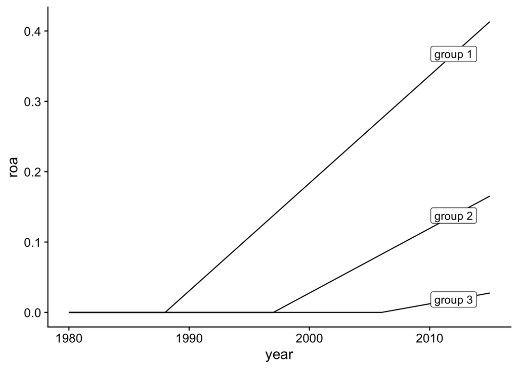

```r
plot_dt <- data.table(year = rep(1980:2015, 3),
                      group = rep(1:3, each = 36))
plot_dt[, `:=`(roa = pmax(year - treatment_groups[group] + 1, 0)
               * treatment_effects[group] * sigma_roa,
               label = ifelse(year == 2012, paste("group", group, sep = " "),
                              NA))]
effect_plot <- ggplot(plot_dt, aes(y = roa, x = year, group = group,
                                   label = label)) +
  geom_line() +
  geom_label()
save_plot(here("slides", "figures", "baker_effects.svg"), effect_plot)
print(effect_plot)
```

The actual data simulation is in the `new_sample` function which again mostly uses `data.table`. The function goes through the following steps. I think I am adding more variation than the Baker et al. paper. So this is by no means a one-for-one replication but it allows me to build on extensions if I so want.

1. Each firm in the firm gets allocated a random firm fixed effect based on the empirical distribution of the firm fixed effects and gets allocated to one of 50 states.
2. Based on the state, I assign the firm to a treatment group and treatment effect.
3. Each year gets a randomly sampled year fixed effect based on the empirical distribution.
4. The two fixed effects are merged to the firm-year `observations`.
5. The simulated ROA is calculated based on the fixed effects, the treatment effect, and random residuals.

During the development of the function I kept track of the timing of the function. Overall, I am quite impressed how fast this was.

```r
new_sample <- function(){
  sample_firms <- firms[, `:=`(
    fef = sample(fef, .N, TRUE),
    state = sample(1:50, .N, TRUE))]
  sample_firms[, state_treatment := state_treatments[state]]
  sample_firms[, `:=`(
    treatment_group = treatment_groups[state_treatment],
    treatment_effect = treatment_effects[state_treatment])]
  sample_years <- years[, fey := sample(fey, .N, TRUE)]
  new <- observations[
    sample_firms, on = .(firm = firm)][
    sample_years, on = .(year = year)]
  new[, treatment := treatment_effect *
          sigma_roa * pmax(year - treatment_group + 1, 0)]
  new[, roa := treatment + fef + fey + sample(residuals, .N, TRUE)]
  new[, rel_year := year - treatment_group]
  return(as.data.table(new))
}
microbenchmark::microbenchmark(sample = new_sample(), times = 100)
```

```
## Unit: milliseconds
##    expr      min       lq     mean   median       uq      max neval
##  sample 65.35324 72.11319 92.61191 75.06027 79.47484 201.1201   100
```

# Analyse

For now I just focus on two estimators. The traditional two-way fixed effect estimator and the [Sun and Abraham](https://doi.org/10.1016/j.jeconom.2020.09.006) estimator. I choose the latter out of the many options because it’s easy to implement as a fixed effect regression and conceptually easy to explain because the hard work is done by only using the appropriate data which allows for the appropriate comparison.

## Two-way Fixed Effects

```r
new <- new_sample()
twoway <- feols(roa ~ ifelse(year >= treatment_group, 1, 0)| year + firm,
                cluster = "state", data = new)
etable(twoway)
```

```
##                                                twoway
## Dependent Var.:                                   roa
##
## ifelse(year>=treatment_group,1,0) -0.0166*** (0.0024)
## Fixed-Effects:                    -------------------
## year                                              Yes
## firm                                              Yes
## _________________________________ ___________________
## S.E.: Clustered                             by: state
## Observations                                  180,463
## R2                                            0.72618
## Within R2                                     0.00049
```

```r
coefficients(twoway)
```

```
## ifelse(year >= treatment_group, 1, 0)
##                           -0.01664183
```

## Sun and Abraham

### Explanation of Sample Selection

The hard work is done by making sure that we make no invalid comparisons. I try to explain this with the following figure. I assume we are only interested in the treatment effect 5 years after the implementation of the treatment. For group 3 who gets the treatment last, there is not appropriate control group (`no_control_group`) so we do not use this group after the treatment. For the other groups, we delete the data more than 5 years after treatment (`no_interest`). We are left with controls which are all pre treatment (`control`) and the 5 years of treatment in group 1 and 2 (`treatment`).

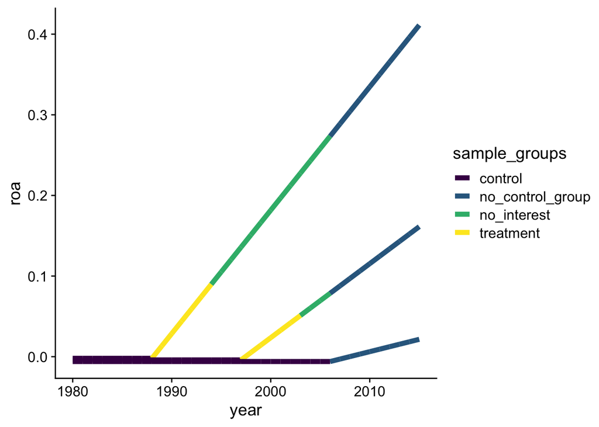

```r
plot_dt[, `:=`(
  roa = roa - 0.002 * group,
  sample_groups = case_when(
    year >= 2007 - 1 ~ "no_control_group",
    year - treatment_groups[group] > 5 - 1 ~ "no_interest",
    year < treatment_groups[group] - 1 ~ "control",
    year >= treatment_groups[group] - 1 ~ "treatment"
  ))]
sun_plot <- ggplot(plot_dt, aes(y = roa, x = year, group = group,
                                label = label, colour = sample_groups)) +
  geom_line(size = 2) +
  viridis::scale_colour_viridis(discrete = T)
save_plot(here("slides", "figures", "baker_sun_sample.svg"), sun_plot)
print(sun_plot)
```

### The code

The actual code to run the Sun and Abraham estimator is available in `fixest`. We first need to construct the cleaned data set following the figure above. Next, we run the regression with `fixest` and use the `sunab` function, which automatically creates indicators for each relative year - treatment group combination. It excludes `rel_year = -1` which is the year before the treatment and the benchmark to which all the estimated coefficients can be compared.

The default output for the Sun and Abraham estimator is to report the aggregated[^6] relative time coefficients. The overall average treatment effect can be extracted with the summary function.

```r
max_rel_year <- 5
sa_new <- new_sample() %>%
  filter(year < treatment_group | rel_year <= max_rel_year) %>%
  filter(year < 2007)
saveRDS(sa_new, here("data", "sa_new.RDS"))
sun_ab <- feols(roa ~ 1 + sunab(treatment_group, year)
                | firm + year, cluster = "state", data = sa_new)
modelsummary(sun_ab, gof_omit = gof_omit, stars = stars)
```

|  | Model 1 |
| --- | --- |
| year = -18 | −0.008 |
|  | (0.007) |
| year = -17 | 0.003 |
|  | (0.011) |
| year = -16 | 0.010 |
|  | (0.009) |
| year = -15 | 0.010 |
|  | (0.007) |
| year = -14 | 0.001 |
|  | (0.009) |
| year = -13 | 0.008 |
|  | (0.010) |
| year = -12 | 0.012 |
|  | (0.009) |
| year = -11 | 0.007 |
|  | (0.009) |
| year = -10 | 0.001 |
|  | (0.009) |
| year = -9 | 0.007 |
|  | (0.005) |
| year = -8 | −0.003 |
|  | (0.007) |
| year = -7 | 0.008 |
|  | (0.006) |
| year = -6 | 0.013** |
|  | (0.006) |
| year = -5 | 0.008 |
|  | (0.007) |
| year = -4 | 0.002 |
|  | (0.006) |
| year = -3 | 0.000 |
|  | (0.007) |
| year = -2 | −0.001 |
|  | (0.007) |
| year = 0 | 0.017*** |
|  | (0.005) |
| year = 1 | 0.017*** |
|  | (0.006) |
| year = 2 | 0.045*** |
|  | (0.006) |
| year = 3 | 0.058*** |
|  | (0.005) |
| year = 4 | 0.061*** |
|  | (0.006) |
| year = 5 | 0.068*** |
|  | (0.006) |
| Num.Obs. | 116804 |
| R2 | 0.726 |
| R2 Within | 0.005 |
| Std.Errors | by: state |
| FE: firm | X |
| FE: year | X |

* p < 0.1, ** p < 0.05, *** p < 0.01

```r
ATT <- coeftable(summary(sun_ab, agg = "ATT"))[1,1]
print(ATT)
```

```
## [1] 0.04432704
```

### Explanation of the code

You can extract the individual coefficients for each relative year - treatment group estimation.

```r
sun_ab$coefficients
```

```
## year::-18:cohort::1998 year::-17:cohort::1998 year::-16:cohort::1998
##          -0.0082494467           0.0028572851           0.0101141122
## year::-15:cohort::1998 year::-14:cohort::1998 year::-13:cohort::1998
##           0.0101610760           0.0007543774           0.0080781327
## year::-12:cohort::1998 year::-11:cohort::1998 year::-10:cohort::1998
##           0.0122408827           0.0069127960           0.0013375669
##  year::-9:cohort::1989  year::-9:cohort::1998  year::-8:cohort::1989
##           0.0092357044           0.0052578621          -0.0020957910
##  year::-8:cohort::1998  year::-7:cohort::1989  year::-7:cohort::1998
##          -0.0044519689           0.0080606231           0.0082946600
##  year::-6:cohort::1989  year::-6:cohort::1998  year::-5:cohort::1989
##           0.0064570844           0.0185239744           0.0059209553
##  year::-5:cohort::1998  year::-4:cohort::1989  year::-4:cohort::1998
##           0.0103596661           0.0051417945          -0.0008810520
##  year::-3:cohort::1989  year::-3:cohort::1998  year::-2:cohort::1989
##          -0.0027516388           0.0024618163           0.0074936022
##  year::-2:cohort::1998   year::0:cohort::1989   year::0:cohort::1998
##          -0.0065395919           0.0344519151           0.0046164554
##   year::1:cohort::1989   year::1:cohort::1998   year::2:cohort::1989
##           0.0268651879           0.0094308991           0.0597877058
##   year::2:cohort::1998   year::3:cohort::1989   year::3:cohort::1998
##           0.0340877096           0.0837993846           0.0373036570
##   year::4:cohort::1989   year::4:cohort::1998   year::5:cohort::1989
##           0.0868842311           0.0370824371           0.0917522639
##   year::5:cohort::1998
##           0.0456563536
```

```r
summary(sun_ab, agg = "cohort") %>%
  msummary(gof_omit = gof_omit, stars = stars)
```

|  | Model 1 |
| --- | --- |
| cohort = 1989 | 0.065*** |
|  | (0.006) |
| cohort = 1998 | 0.027*** |
|  | (0.006) |
| Num.Obs. | 116804 |
| R2 | 0.726 |
| R2 Within | 0.005 |
| Std.Errors | by: state |
| FE: firm | X |
| FE: year | X |

* p < 0.1, ** p < 0.05, *** p < 0.01

## True ATT

The true ATT will be different if we use the full sample or restrict the treated observations to 5 years after the treatment for group 1 and 2. The following code calculates the expected true ATT for the full sample or by cohort. The `true_att` calculation exploits the linear increase in the treatment effect.

```r
true_full_att <- mean((2016 - treatment_groups)/2 *
                      sigma_roa * treatment_effects)
true_att <- (max_rel_year + 2)/2 * sigma_roa * treatment_effects
print(true_full_att)
```

```
## [1] 0.1010209
```

```r
print(true_att)
```

```
## [1] 0.05357167 0.03214300 0.01071433
```

```r
collap(new[rel_year %in% 0:5], treatment ~ rel_year + treatment_group) %>%
  collap(treatment ~ treatment_group)
```

```
##    treatment_group  treatment
## 1:            1989 0.05357167
## 2:            1998 0.03214300
## 3:            2007 0.01071433
```

# Simulation

Everything is now in place to run a simulation that simulates new data and runs the two-way fixed effect OLS estimator and the Sun and Abraham one. I extract the estimate of the ATT from both and save them as the `results`.

The rest of the code runs the simulation `nsim` times and plots the estimate with the expected true ATT.

```r
nsim <- 500
simulate <- function(sim = 1){
  new <- new_sample()
  twoway <- feols(roa ~ ifelse(year >= treatment_group, 1, 0)
                  | year + firm, data = new)
  twoway_coef = coefficients(twoway)[1]
  sa_new <- new[(year < treatment_group | rel_year <= 5) & year < 2007]
  sun_ab  <- feols(roa ~ 1 + sunab(treatment_group, year)
                   | firm + year, sa_new)
  sun_ab_att <- coeftable(summary(sun_ab, agg = "ATT"))[1,1]
  results <- c(twoway_coef, sun_ab_att)
  names(results) <- c("twoway", "sun_abraham")
  return(results)
}
simulate()
```

```
##      twoway sun_abraham
## -0.01204308  0.04170990
```

```r
estimates <- parallel::mclapply(1:nsim, FUN = simulate, mc.cores = 4L) %>%
  bind_rows()
summary(estimates)
```

```
##      twoway          sun_abraham
##  Min.   :-0.02017   Min.   :0.02827
##  1st Qu.:-0.01565   1st Qu.:0.03866
##  Median :-0.01441   Median :0.04163
##  Mean   :-0.01443   Mean   :0.04184
##  3rd Qu.:-0.01302   3rd Qu.:0.04524
##  Max.   :-0.00933   Max.   :0.05747
```

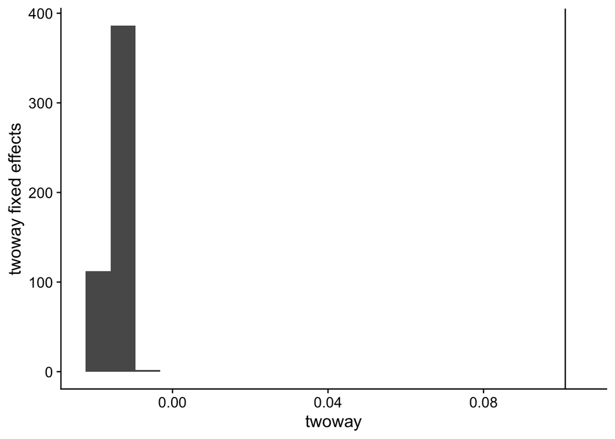

```r
sim_twoway <- ggplot(estimates, aes(x = twoway)) +
  geom_histogram(bins = 20) +
  ylab("twoway fixed effects") +
  geom_vline(xintercept = true_full_att)
sim_sun_abraham <- ggplot(estimates, aes(x = sun_abraham)) +
  geom_histogram(bins = 20) +
  ylab("Sun and Abraham") +
  geom_vline(xintercept = mean(true_att[1:2]))
save_plot(here("slides", "figures", "simulation_twoway.svg"), sim_twoway)
save_plot(here("slides", "figures", "simulation_sun_abraham.svg"), sim_sun_abraham)
print(sim_twoway)
```

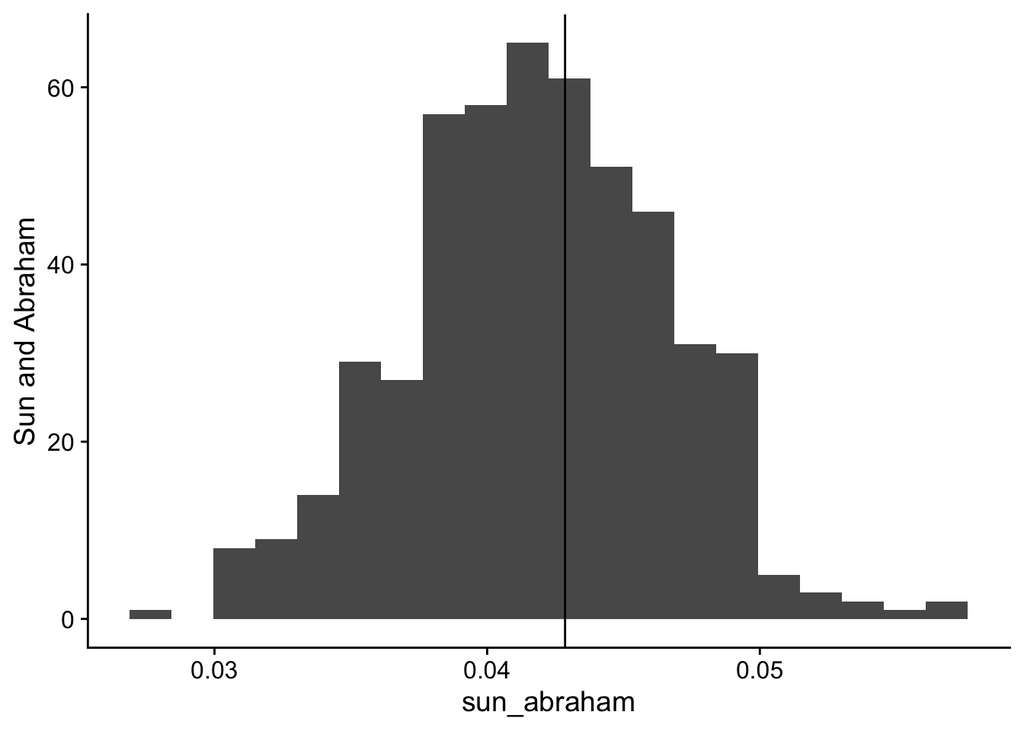

```r
print(sim_sun_abraham)
```

[^1]: You may or may not be interested in this but there you go. It’s free.
[^2]: This whole document knits in less than 10 minutes on my 2014 MacBook Pro. I am quite pleased with this.
[^3]: I do not.
[^4]: Which is not necessarily a given. See [this terrifying looking paper.](https://papers.ssrn.com/sol3/papers.cfm?abstract_id=3930228)
[^5]: This is slightly different than in the Baker et al. paper. I allow that by random chance some of the groups are larger than the other while the Baker et al. simulation keeps the groups (almost) equal in size. I was too lazy to change it when I noticed the difference but I am also interested in what happens to the average treatment effect if some group effects are estimated more precisely so my simulation is at least consistent with that goal
[^6]: over the groups